# What makes human cognition distinctive ?

In this notebook I explore human intelligence in a simple, reproducible way. I collected findings from neuroscience and cognitive science, then turned them into clear figures with short explanations. My goal was to show, in one place, what makes human thinking special, how stable intelligence stays over a lifetime, and how the brain changes with learning. I also mark clearly which figures use real published data and which use illustrative data, so the work stays honest and easy to trust.

The notebook looks at human intelligence through three lenses:

1. **Individual differences.** How stable is intelligence within a person, and what neural properties go with it?
2. **Comparative and evolutionary.** What does the human brain have *more* of, and is any higher ability truly unique to us?
3. **Plasticity.** How does brain structure change with development and learning?

> **A note on the data.** Some figures use real published values. Others use *illustrative* data, made to reproduce a published effect size or trend. These are labelled in the cell above each plot. Full citations are in the Sources section.

© 2026 Aya Bahi. All rights reserved.

## 0 · Setup

```python
import numpy as np
import pandas as pd
import matplotlib.pyplot as plt
import matplotlib.ticker as mticker

# Reproducibility for any illustrative/simulated data
RNG = np.random.default_rng(42)

plt.rcParams.update({
    "figure.figsize": (8, 5),
    "figure.dpi": 110,
    "axes.spines.top": False,
    "axes.spines.right": False,
    "axes.grid": True,
    "grid.alpha": 0.25,
    "font.size": 11,
})

ACCENT = "#c0392b"      # highlight (humans)
NEUTRAL = "#5b7ea3"     # everyone else
print("Setup ready.")
```

```
Setup ready.
```

## 1 · Individual differences in intelligence

Two well-replicated findings guide this section.

- **Intelligence is very stable within a person.** In a large long-term study of children, intelligence at age 11 correlated about 0.81 with school achievement 5 years later, across all 25 subjects. A test at age 11 also predicts the same test taken at age 90 (Deary et al., Lothian Birth Cohort studies).
- **Neural properties track IQ.** Larger human pyramidal neurons with faster action-potential (AP) kinetics go with higher IQ. They allow faster computation and keep AP speed high during rapid firing (Goriounova et al., 2018).

### 1.1 · Stability of intelligence across the lifespan

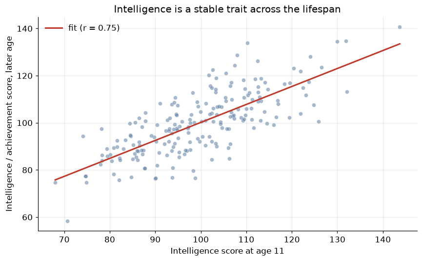

```python
# Illustrative: reproduce a correlation of ~0.81 between age-11 IQ and later score
n = 200
target_r = 0.81

z1 = RNG.standard_normal(n)
z2 = target_r * z1 + np.sqrt(1 - target_r**2) * RNG.standard_normal(n)

iq_11    = 100 + 15 * z1          # standardized IQ scale
iq_later = 100 + 15 * z2

r = np.corrcoef(iq_11, iq_later)[0, 1]

fig, ax = plt.subplots()
ax.scatter(iq_11, iq_later, s=28, alpha=0.55, color=NEUTRAL, edgecolor="white", linewidth=0.4)

# regression line
b, a = np.polyfit(iq_11, iq_later, 1)
xs = np.array([iq_11.min(), iq_11.max()])
ax.plot(xs, a + b * xs, color=ACCENT, lw=2, label=f"fit (r = {r:.2f})")

ax.set_xlabel("Intelligence score at age 11")
ax.set_ylabel("Intelligence / achievement score, later age")
ax.set_title("Intelligence is a stable trait across the lifespan")
ax.legend(frameon=False)
plt.tight_layout()
plt.show()
```

### 1.2 · Neuron speed and IQ

*Illustrative data* that reproduces the reported positive link between action-potential speed (and neuron size) and IQ (Goriounova et al., 2018). What matters here is the **direction and strength** of the link, not the exact points.

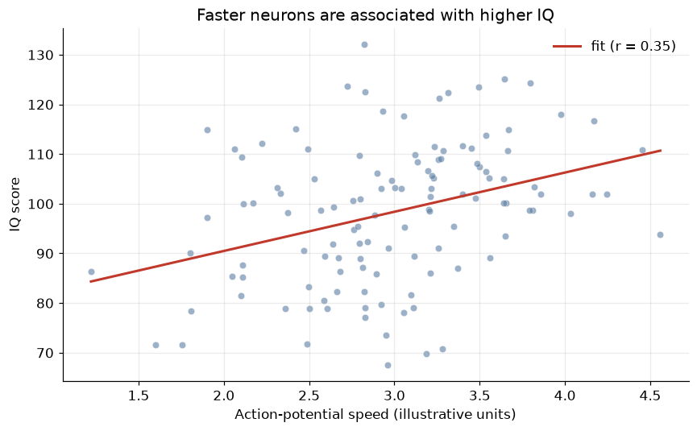

```python
n = 120
r_target = 0.45  # modest, realistic effect

z = RNG.standard_normal(n)
noise = RNG.standard_normal(n)
ap_speed = 3.0 + 0.6 * z                              # arbitrary AP-speed units
iq = 100 + 15 * (r_target * z + np.sqrt(1 - r_target**2) * noise)

r = np.corrcoef(ap_speed, iq)[0, 1]

fig, ax = plt.subplots()
ax.scatter(ap_speed, iq, s=30, alpha=0.6, color=NEUTRAL, edgecolor="white", linewidth=0.4)
b, a = np.polyfit(ap_speed, iq, 1)
xs = np.array([ap_speed.min(), ap_speed.max()])
ax.plot(xs, a + b * xs, color=ACCENT, lw=2, label=f"fit (r = {r:.2f})")

ax.set_xlabel("Action-potential speed (illustrative units)")
ax.set_ylabel("IQ score")
ax.set_title("Faster neurons are associated with higher IQ")
ax.legend(frameon=False)
plt.tight_layout()
plt.show()
```

### 1.3 · What explains differences in intelligence? (variance decomposition)

A pie chart is honest here because these slices **really add up to 100%** of the variance in intelligence *between people*. Twin and adoption studies split that variance into three parts:

- **Genetics (heritability):** differences due to genetic variation.
- **Shared environment:** family, home, and schooling shared by siblings.
- **Non-shared environment and error:** unique experiences and measurement noise.

**Illustrative** mid-range values for adults. Two important points to keep in mind. First, the heritability of intelligence *rises with age* (the Wilson effect: roughly 20–40% in childhood, up to 60–80% in adulthood). Second, heritability describes **variance in a group, not in one person**. It does *not* mean that 50% of *your* intelligence is "genetic."

Twin studies put the heritability of intelligence high, often in the 50–80% range (up to 86% for verbal IQ), which makes it one of the most heritable behavioural traits (Plomin & Deary, 2015; Goriounova & Mansvelder, 2019). The 50% genetics slice above is an illustrative mid-range value that sits inside this real range.

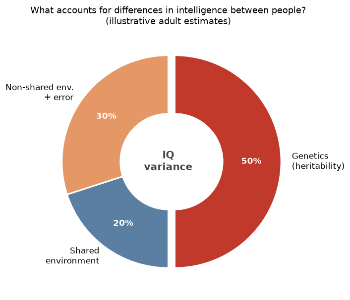

```python
# Illustrative variance decomposition of intelligence (adult, mid-range twin-study values)
components = ["Genetics\n(heritability)", "Shared\nenvironment", "Non-shared env.\n+ error"]
shares = [50, 20, 30]                      # % of between-person variance; sums to 100
colors = [ACCENT, NEUTRAL, "#e59866"]
explode = [0.06, 0, 0]                     # nudge the genetics slice out

fig, ax = plt.subplots(figsize=(6.5, 6.5))
wedges, texts, autotexts = ax.pie(
    shares, labels=components, colors=colors, explode=explode,
    autopct="%1.0f%%", startangle=90, counterclock=False,
    wedgeprops=dict(width=0.55, edgecolor="white", linewidth=2),  # donut style
    pctdistance=0.72,
)
for t in autotexts:
    t.set_color("white"); t.set_fontweight("bold"); t.set_fontsize(11)

ax.set_title("What accounts for differences in intelligence between people?\n(illustrative adult estimates)", fontsize=12)
ax.text(0, 0, "IQ\nvariance", ha="center", va="center", fontsize=13, fontweight="bold", color="#444")
ax.set_aspect("equal")
plt.tight_layout()
plt.show()
```

### 1.4 · Cells of intelligence: human vs rodent neurons

Why might larger, faster neurons help intelligence? Living human brain tissue, removed during surgery, lets researchers measure single human neurons. Human layer 2/3 pyramidal neurons (the brain's main integrators) differ a lot from rodent ones.

**Real published data** (Goriounova & Mansvelder, 2019, reviewing Mohan et al., 2015; DeFelipe et al., 2002; Testa-Silva et al., 2014). Each value shows how many times larger the human number is than the rodent one. The rodent baseline is set to 1.

Recent work links these cell features to IQ. Higher IQ goes with a thicker temporal cortex, larger and more complex dendrites, and faster action potentials with sustained firing (Goriounova et al., 2018).

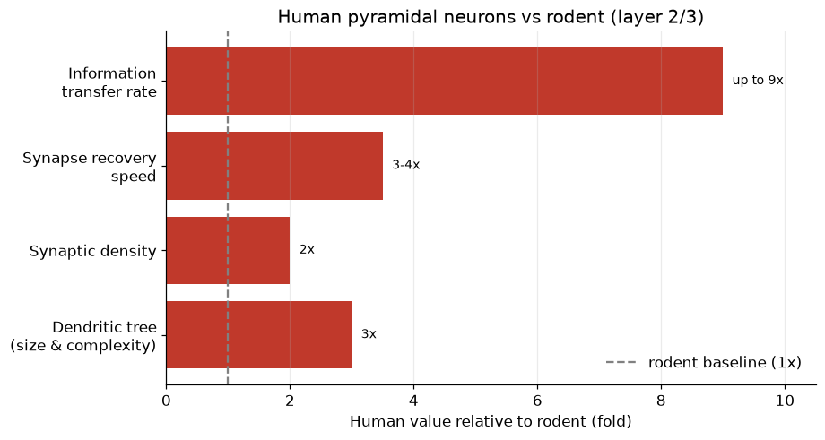

```python
# REAL DATA: human vs rodent layer 2/3 pyramidal neurons (fold difference, rodent = 1)
# Source: Goriounova & Mansvelder (2019), reviewing Mohan 2015, DeFelipe 2002, Testa-Silva 2014
neuron = pd.DataFrame({
    "property": ["Dendritic tree\n(size & complexity)", "Synaptic density",
                 "Synapse recovery\nspeed", "Information\ntransfer rate"],
    "fold":  [3.0, 2.0, 3.5, 9.0],
    "label": ["3x", "2x", "3-4x", "up to 9x"],
})

fig, ax = plt.subplots(figsize=(8.5, 4.6))
bars = ax.barh(neuron["property"], neuron["fold"], color=ACCENT)
ax.axvline(1, color="gray", ls="--", lw=1.5, label="rodent baseline (1x)")
for b, lab in zip(bars, neuron["label"]):
    ax.text(b.get_width() + 0.15, b.get_y() + b.get_height() / 2, lab, va="center", fontsize=9)
ax.set_xlabel("Human value relative to rodent (fold)")
ax.set_title("Human pyramidal neurons vs rodent (layer 2/3)")
ax.set_xlim(0, 10.5)
ax.legend(frameon=False, loc="lower right")
ax.grid(axis="y", visible=False)
plt.tight_layout()
plt.show()
```

### 1.5 · The genetics of intelligence

Intelligence is highly heritable, but no single gene explains it (b7al ga3 l human caracterstics lakhrin li mazal mal9ina lihoum footprint f l epigenetics). It is **polygenic**: thousands of common variants each add a tiny effect (usually less than 0.1% each). Large genome-wide studies (GWAS) so far capture about 20–22% of the SNP heritability (Savage et al., 2018; Lam et al., 2017).

There is also a striking pattern in *where* these variants sit. Only about 1.4% are exonic (protein-coding). Most are intronic or intergenic, in regions that help control when and where genes switch on (Savage et al., 2018).

**Real published data** below (Savage et al., 2018), shown as the share of intelligence-associated SNPs by genome location. The slices add up to 100%. The "other" slice covers the remaining regions, for example UTRs and non-coding RNA.

The takeaway: Intelligence isn't shaped by DNA changes that rewrite proteins, but mostly by changes that fine-tune gene activity, often in response to experience and environment !!

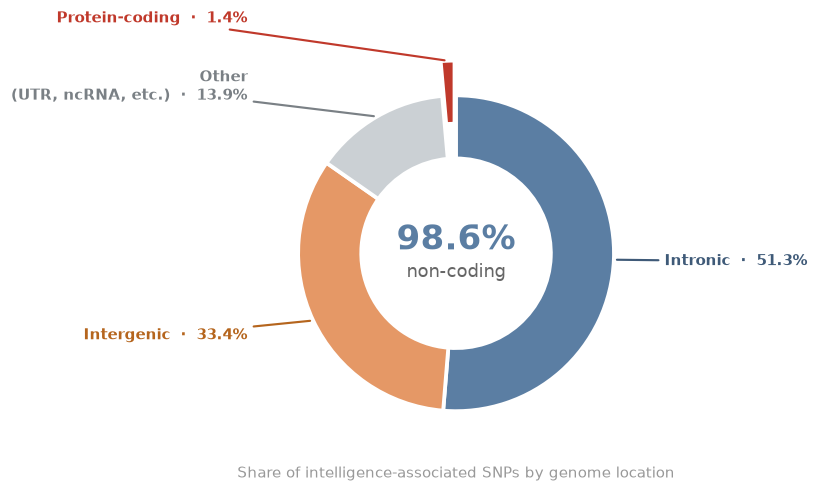

```python
# REAL DATA: where intelligence-associated SNPs sit in the genome (Savage et al., 2018)
labels  = ["Intronic", "Intergenic", "Other\n(UTR, ncRNA, etc.)", "Protein-coding"]
shares  = [51.3, 33.4, 13.9, 1.4]           # sums to 100
colors  = [NEUTRAL, "#e59866", "#cbd0d4", ACCENT]
explode = [0, 0, 0, 0.22]                    # pull the tiny coding slice out

fig, ax = plt.subplots(figsize=(7.4, 7.4))
wedges, _ = ax.pie(
    shares, colors=colors, explode=explode,
    startangle=90, counterclock=False,
    wedgeprops=dict(width=0.40, edgecolor="white", linewidth=2.5),
)

# --- center takeaway (matches the donut style used in 1.3) ---
ax.text(0, 0.08, "98.6%", ha="center", va="center",
        fontsize=22, fontweight="bold", color=NEUTRAL)
ax.text(0, -0.12, "non-coding", ha="center", va="center",
        fontsize=12, color="#666")

# --- tidy leader-line labels (name + %) so nothing overlaps ---
text_col = ["#3f5a78", "#b5651d", "#7a8085", ACCENT]   # darker, legible versions of each slice
for w, name, share, col, ex in zip(wedges, labels, shares, text_col, explode):
    ang  = np.deg2rad((w.theta1 + w.theta2) / 2)
    x, y = np.cos(ang), np.sin(ang)
    r    = 1.0 + ex                                      # follow the exploded wedge outward
    ha   = "left" if x >= 0 else "right"
    ax.annotate(
        f"{name}  ·  {share:.1f}%",
        xy=(r * x, r * y), xytext=(1.32 * np.sign(x), 1.22 * r * y),
        ha=ha, va="center", fontsize=10, fontweight="bold", color=col,
        arrowprops=dict(arrowstyle="-", color=col, lw=1.4,
                        connectionstyle="arc3,rad=0.0"),
    )


ax.text(0.5, -0.04, "Share of intelligence-associated SNPs by genome location",
        transform=ax.transAxes, ha="center", va="top", fontsize=9.5, color="#999")
ax.set_xlim(-1.5, 1.5)
ax.set_aspect("equal")
plt.tight_layout()
plt.show()
```

## 2 · Comparative and evolutionary cognition

Main claim from the source material: **no higher cognitive ability is truly unique to humans. Precursors exist in other species. Yet humans are always "on top."** How did this happen? Cortical volume grew a lot during evolution. This raised the *number* of cortical neurons, while keeping the high packing density and conduction velocity typical of primates.

### 2.1 · Cortical neurons across species

**Real published data** (Herculano-Houzel and colleagues), shown in *billions* of cerebral-cortex neurons. Look at the African elephant. It has far more *total* brain neurons than a human, but most sit in the cerebellum. Its **cortical** neuron count is well below ours, and that is the number linked to higher cognition.

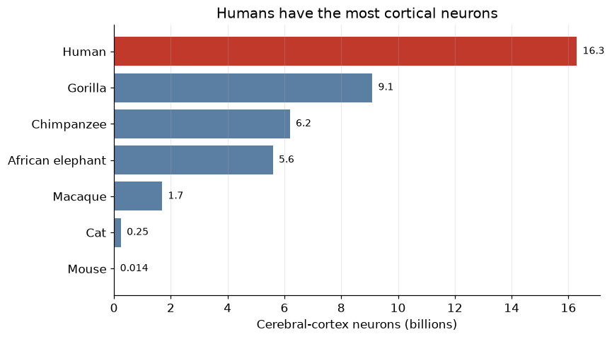

```python
species = pd.DataFrame({
    "species": ["Mouse", "Cat", "Macaque", "African elephant",
                "Chimpanzee", "Gorilla", "Human"],
    "cortical_neurons_billion": [0.014, 0.25, 1.7, 5.6, 6.2, 9.1, 16.3],
}).sort_values("cortical_neurons_billion")

colors = [ACCENT if s == "Human" else NEUTRAL for s in species["species"]]

fig, ax = plt.subplots(figsize=(8, 4.5))
ax.barh(species["species"], species["cortical_neurons_billion"], color=colors)
ax.set_xlabel("Cerebral-cortex neurons (billions)")
ax.set_title("Humans have the most cortical neurons")
for y, v in enumerate(species["cortical_neurons_billion"]):
    ax.text(v + 0.2, y, f"{v:g}", va="center", fontsize=9)
ax.grid(axis="y", visible=False)
plt.tight_layout()
plt.show()
```

### 2.2 · Brain mass vs body mass (encephalization)

**Illustrative** log–log scatter across mammals, with humans highlighted. Humans sit *above* the general trend line, so they have more brain than body size alone would predict. Swap in a real EQ or brain-mass table for a publication-grade version.

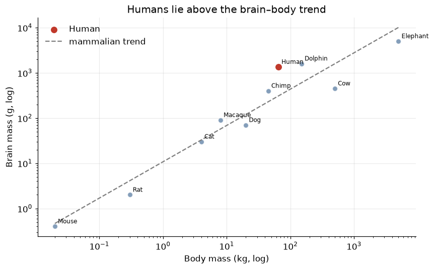

```python
data = pd.DataFrame({
    "animal": ["Mouse", "Rat", "Cat", "Dog", "Macaque", "Chimp",
               "Human", "Cow", "Elephant", "Dolphin"],
    "body_kg":  [0.02, 0.3, 4, 20, 8, 45, 65, 500, 5000, 150],
    "brain_g":  [0.4, 2, 30, 70, 90, 400, 1350, 450, 5000, 1600],
})

fig, ax = plt.subplots()
is_human = data["animal"] == "Human"
ax.scatter(data.loc[~is_human, "body_kg"], data.loc[~is_human, "brain_g"],
           s=45, color=NEUTRAL, alpha=0.75, edgecolor="white")
ax.scatter(data.loc[is_human, "body_kg"], data.loc[is_human, "brain_g"],
           s=90, color=ACCENT, edgecolor="white", zorder=3, label="Human")

# trend line fit in log space
lx, ly = np.log10(data["body_kg"]), np.log10(data["brain_g"])
b, a = np.polyfit(lx, ly, 1)
xs = np.logspace(np.log10(data["body_kg"].min()), np.log10(data["body_kg"].max()), 100)
ax.plot(xs, 10**(a) * xs**b, color="gray", ls="--", lw=1.5, label="mammalian trend")

for _, row in data.iterrows():
    ax.annotate(row["animal"], (row["body_kg"], row["brain_g"]),
                fontsize=8, xytext=(4, 4), textcoords="offset points")

ax.set_xscale("log"); ax.set_yscale("log")
ax.set_xlabel("Body mass (kg, log)")
ax.set_ylabel("Brain mass (g, log)")
ax.set_title("Humans lie above the brain–body trend")
ax.legend(frameon=False)
plt.tight_layout()
plt.show()
```

### 2.3 · Ten cognitive abilities across species

The argument shown directly: each higher ability has **precursors** in other animals (few cells are empty), but humans show the fullest form across the board.

**Illustrative "evidence strength" ratings** (0 = little or no evidence, 3 = strong evidence). They summarize the qualitative literature and are *not* a formal meta-analysis. Treat this as a teaching schematic, and cite primary sources before making strong claims.

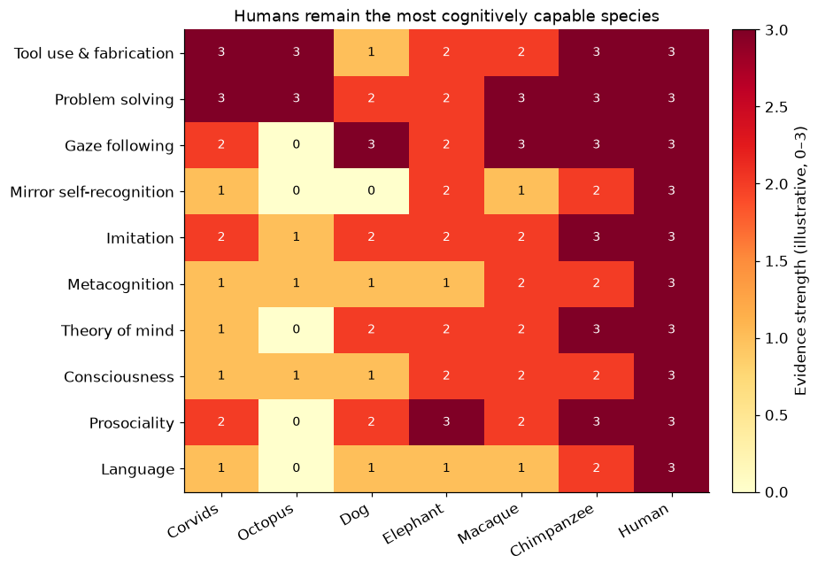

```python
abilities = ["Tool use & fabrication", "Problem solving", "Gaze following",
             "Mirror self-recognition", "Imitation", "Metacognition",
             "Theory of mind", "Consciousness", "Prosociality", "Language"]
species_cols = ["Corvids", "Octopus", "Dog", "Elephant",
                "Macaque", "Chimpanzee", "Human"]

# rows = abilities, cols = species; illustrative 0-3 ratings
matrix = np.array([
    [3, 3, 1, 2, 2, 3, 3],  # tool use
    [3, 3, 2, 2, 3, 3, 3],  # problem solving
    [2, 0, 3, 2, 3, 3, 3],  # gaze following
    [1, 0, 0, 2, 1, 2, 3],  # mirror self-recognition
    [2, 1, 2, 2, 2, 3, 3],  # imitation
    [1, 1, 1, 1, 2, 2, 3],  # metacognition
    [1, 0, 2, 2, 2, 3, 3],  # theory of mind
    [1, 1, 1, 2, 2, 2, 3],  # consciousness
    [2, 0, 2, 3, 2, 3, 3],  # prosociality
    [1, 0, 1, 1, 1, 2, 3],  # language
])

fig, ax = plt.subplots(figsize=(8.5, 6))
im = ax.imshow(matrix, cmap="YlOrRd", aspect="auto", vmin=0, vmax=3)

ax.set_xticks(range(len(species_cols)), species_cols, rotation=30, ha="right")
ax.set_yticks(range(len(abilities)), abilities)
ax.set_title("Humans remain the most cognitively capable species", fontsize=12)

for i in range(matrix.shape[0]):
    for j in range(matrix.shape[1]):
        ax.text(j, i, matrix[i, j], ha="center", va="center",
                color="black" if matrix[i, j] < 2 else "white", fontsize=9)

cbar = fig.colorbar(im, ax=ax, fraction=0.046, pad=0.04)
cbar.set_label("Evidence strength (illustrative, 0–3)")
ax.grid(False)
plt.tight_layout()
plt.show()
```

## 3 · Plasticity: the brain changes with development and learning

Gray-matter volume changes across childhood *and* adulthood. It is shaped by learning, experience, hormones, and age. These changes likely reflect the rearrangement of dendrites and synapses (Gogtay et al., 2004). Learning a real skill can produce a measurable structural change, which is sometimes **transient**.

### 3.1 · Gray matter across the lifespan

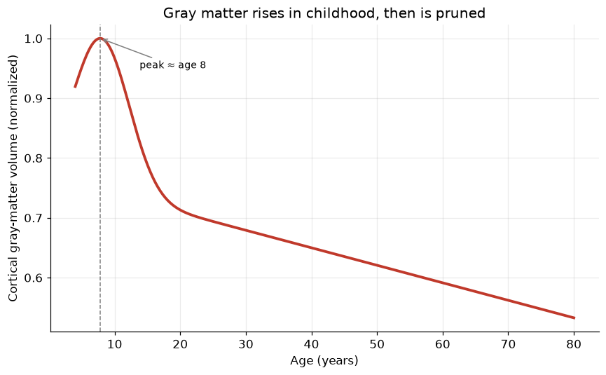

```python
age = np.linspace(4, 80, 400)
# schematic: rise to a peak ~12, then gradual decline
gm = 1.0 + 0.35 * np.exp(-((age - 8) / 6) ** 2) - 0.004 * (age - 12)
gm = gm / gm.max()

fig, ax = plt.subplots()
ax.plot(age, gm, color=ACCENT, lw=2.5)
peak_age = age[np.argmax(gm)]
ax.axvline(peak_age, color="gray", ls="--", lw=1)
ax.annotate(f"peak ≈ age {peak_age:.0f}", (peak_age, gm.max()),
            xytext=(peak_age + 6, gm.max() - 0.05),
            arrowprops=dict(arrowstyle="->", color="gray"), fontsize=9)
ax.set_xlabel("Age (years)")
ax.set_ylabel("Cortical gray-matter volume (normalized)")
ax.set_title("Gray matter rises in childhood, then is pruned")
plt.tight_layout()
plt.show()
```

### 3.2 · The juggling study

Draganski et al. (2004) found gray-matter increases in visual-motion areas (hMT/V5) after adults learned to juggle. These changes **partly reverted** once training stopped.

**Illustrative** values that reproduce the reported rise-and-partial-decline pattern.

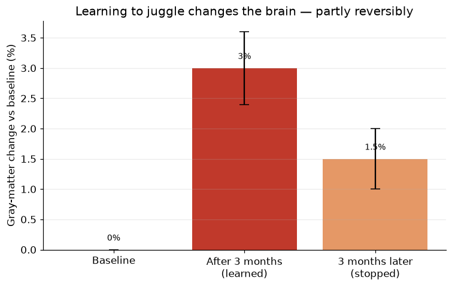

```python
stages = ["Baseline", "After 3 months\n(learned)", "3 months later\n(stopped)"]
gm_change = [0.0, 3.0, 1.5]   # illustrative % change in hMT/V5 gray matter
errors = [0.0, 0.6, 0.5]

fig, ax = plt.subplots(figsize=(7, 4.5))
bars = ax.bar(stages, gm_change, yerr=errors, capsize=5,
              color=[NEUTRAL, ACCENT, "#e59866"])
ax.set_ylabel("Gray-matter change vs baseline (%)")
ax.set_title("Learning to juggle changes the brain — partly reversibly")
for b, v in zip(bars, gm_change):
    ax.text(b.get_x() + b.get_width()/2, v + 0.15, f"{v:g}%",
            ha="center", fontsize=9)
ax.grid(axis="x", visible=False)
plt.tight_layout()
plt.show()
```

## 4 · Takeaways

- **Within a person, intelligence is very stable** from childhood into old age.
- **Neuronal properties matter.** Larger, faster human neurons go with higher IQ.
- **Nothing higher is uniquely human.** Precursors of every ability appear in other species. But humans express the full set most strongly. This is likely helped by a large number of cortical neurons, at high packing density and conduction velocity, together with syntactic language.
- **The brain stays plastic.** Its structure changes with development and with real learning, sometimes only for a while.
- **Metacognition may be the keystone ability.** It is the monitoring and control of your own thinking, which lets a mind judge the *reliability* of its judgments. It has a distinct prefrontal basis (Fleming & Dolan, 2012), it shapes social decisions and accountability (Bao et al., 2026), and it supports learning.

### 4.1 · Why metacognition matters

Among the ten abilities, **metacognition** (thinking about thinking) deserves a closer look. It does something the others do not: it judges the *reliability* of a mind's own judgments, instead of just producing them. Several lines of evidence make it central to human intelligence.

- **It is a skill on its own, with its own neural basis.** How well a person's confidence matches their real accuracy varies from person to person. It is linked to the structure and function of the **anterior prefrontal cortex**, and it is partly *separate from task performance itself* (Fleming & Dolan, 2012). Being accurate, and *knowing* how accurate you are, are two different skills.
- **It has social effects.** Deciding for other people changes how metacognition works and creates **responsibility aversion**. This is a measurable reluctance to choose for others, driven by shifts in confidence and self-evaluation (Bao et al., 2026). So metacognition shapes delegation, accountability, and trust, not just private reasoning.
- **It drives self-regulated learning.** Knowing what you don't know tells you when to study more, look for information, or change a belief. Good calibration is very valuable for education and for learning new skills.
- **It ties this notebook's three threads together.** Metacognition is an *individual difference* (it varies between people and has neural correlates, §1), it has *evolutionary precursors* (uncertainty-monitoring in monkeys and dolphins, §2), and it is *plastic* (calibration can be trained, §3).

### 4.2 · The same picture in **real data**

**Source.** Lund, Correa, Fardo, Fleming & Allen (2023), *Domain Generality in Metacognitive Ability*. This is a pre-registered study of **322 participants** and **~193,000 trials**. On each trial, a participant made a 2-alternative choice and then rated confidence on a **1–7 scale**. They did this across four domains: **vision**, **memory**, and two general-knowledge tasks (**GDP** = which country is wealthier, **Calories** = which food has more calories). The data are openly available in the study's repository.

The cell below downloads the raw trial-level data from that repository. For each confidence level, it computes the **real proportion of correct answers**. If confidence is meaningful, accuracy should rise steadily with reported confidence. That is calibration, measured, not drawn.

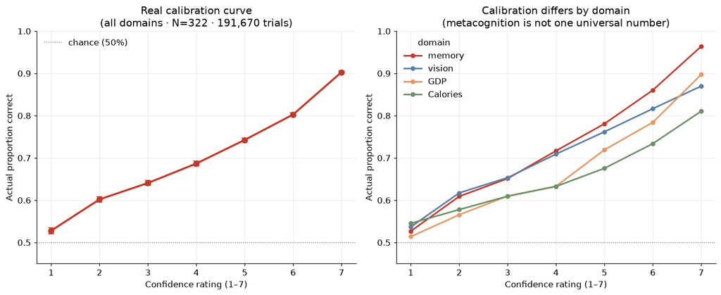

```
Overall calibration (confidence -> proportion correct):
             mean  count
confidence
1.0         0.528  19345
2.0         0.602  21518
3.0         0.641  24180
4.0         0.687  24921
5.0         0.743  31121
6.0         0.803  25423
7.0         0.903  45162
```

```python
# REAL DATA: calibration curve from Lund et al. (2023), Domain-General Metacognition
# 322 participants, ~193k trials, confidence rated 1-7. Data pulled live from the study repo.
import os

RAW_URL = ("https://raw.githubusercontent.com/embodied-computation-group/"
           "dg-metacognition/main/data_summary/metacognition_trialData_master.csv")
LOCAL = "metacognition_trialData_master.csv"   # cache after first download

src = LOCAL if os.path.exists(LOCAL) else RAW_URL
trials = pd.read_csv(src, usecols=["modality", "accuracy", "confidence"]).dropna()
if src == RAW_URL:
    try:
        trials.to_csv(LOCAL, index=False)   # cache locally for reruns
    except Exception:
        pass

def calibration(frame):
    g = frame.groupby("confidence")["accuracy"].agg(["mean", "count"])
    g["se"] = np.sqrt(g["mean"] * (1 - g["mean"]) / g["count"])   # binomial SE
    return g

fig, (axA, axB) = plt.subplots(1, 2, figsize=(13, 5.4))

# --- Panel A: overall calibration (real counterpart of the §4.1 schematic) ---
ov = calibration(trials)
axA.errorbar(ov.index, ov["mean"], yerr=1.96 * ov["se"], marker="o", ms=7,
             lw=2.5, capsize=4, color=ACCENT)
axA.axhline(0.5, color="gray", ls=":", lw=1, label="chance (50%)")
axA.set_xlabel("Confidence rating (1–7)")
axA.set_ylabel("Actual proportion correct")
axA.set_title(f"Real calibration curve\n(all domains · N=322 · {len(trials):,} trials)")
axA.set_ylim(0.45, 1.0)
axA.legend(frameon=False, loc="upper left")

# --- Panel B: by domain — metacognition is partly domain-specific ---
domain_colors = {"memory": ACCENT, "vision": NEUTRAL, "GDP": "#e59866", "Calories": "#6c8e68"}
for m, col in domain_colors.items():
    g = calibration(trials[trials.modality == m])
    axB.plot(g.index, g["mean"], marker="o", ms=5, lw=2, color=col, label=m)
axB.axhline(0.5, color="gray", ls=":", lw=1)
axB.set_xlabel("Confidence rating (1–7)")
axB.set_ylabel("Actual proportion correct")
axB.set_title("Calibration differs by domain\n(metacognition is not one universal number)")
axB.set_ylim(0.45, 1.0)
axB.legend(frameon=False, title="domain", loc="upper left")

plt.tight_layout()
plt.show()

print("Overall calibration (confidence -> proportion correct):")
print(ov[["mean", "count"]].round(3))
```

### 4.3 · Gender differences in metacognition

The §4.2 dataset was also used to study gender differences (Hoogervorst et al., 2024, same COBELAB battery). Two findings stand out. On average, women reported **lower confidence** than men (a negative bias). Yet women showed **higher metacognitive efficiency**, which means their confidence tracked their accuracy a little better. In short: less confidence, but sharper self-monitoring.

**Real data**, not illustrative. The left panel is a gender-split calibration curve, computed live from the trial data (172 women, 145 men). The right panel shows the metacognitive-efficiency difference (women minus men) by domain, from the study's hierarchical Bayesian model. A bar above zero means higher efficiency in women. Filled bars mark domains where the 95% interval excludes zero (overall, and the calorie task).

Gender here is each participant's self-reported category. One honest caveat: results on gender and metacognition are mixed. A larger re-analysis across 10 studies found no overall effect (Xue et al., 2024), so treat these differences as real in this sample but not settled across the field.

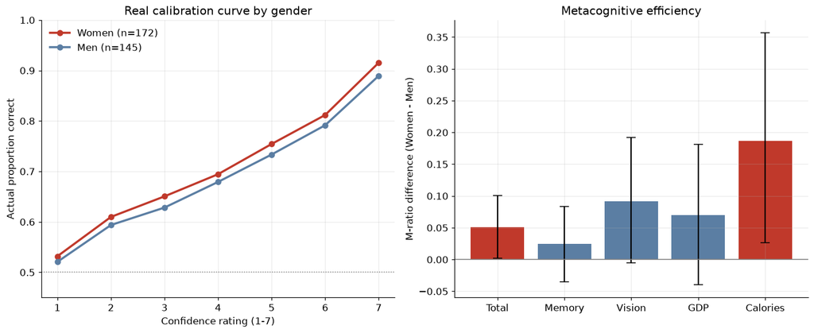

```python
# REAL DATA: gender differences in metacognition (Hoogervorst et al., 2024)
# Same COBELAB battery as sec 4.2. Panel A computed live; Panel B from the paper's model (Table S2).
import os
BASE = "https://raw.githubusercontent.com/embodied-computation-group/metagender/main/data/"

def _load(remote, local):
    if not os.path.exists(local):
        pd.read_csv(BASE + remote).to_csv(local, index=False)
    return pd.read_csv(local)

trials_g = _load("metacognition_TrialData_master.csv", "metagender_trials.csv")
mega     = _load("megatable.csv", "metagender_megatable.csv")

gmap = mega.set_index("Subject")["Gender"].map({"Feminin": "Women", "Masculin": "Men"}).to_dict()
trials_g["gender"] = trials_g["subject"].map(gmap)
tg = trials_g.dropna(subset=["gender", "confidence", "accuracy"])

fig, (axA, axB) = plt.subplots(1, 2, figsize=(13, 5.4))

# Panel A: real gender-split calibration curve
gcolors = {"Women": ACCENT, "Men": NEUTRAL}
for g, col in gcolors.items():
    s = tg[tg.gender == g]
    cal = s.groupby("confidence")["accuracy"].mean()
    axA.plot(cal.index, cal.values, marker="o", ms=6, lw=2.4, color=col,
             label=f"{g} (n={s.subject.nunique()})")
axA.axhline(0.5, color="gray", ls=":", lw=1)
axA.set_xlabel("Confidence rating (1-7)")
axA.set_ylabel("Actual proportion correct")
axA.set_title("Real calibration curve by gender")
axA.set_ylim(0.45, 1.0)
axA.legend(frameon=False, loc="upper left")

# Panel B: metacognitive efficiency difference (Women - Men) by domain, from HMeta-d model (Table S2)
domains = ["Total", "Memory", "Vision", "GDP", "Calories"]
mean = np.array([0.051, 0.025, 0.092, 0.070, 0.187])
lo   = np.array([0.002, -0.035, -0.005, -0.040, 0.026])   # 95% HDI lower
hi   = np.array([0.101,  0.083,  0.192,  0.181, 0.357])   # 95% HDI upper
signif = lo > 0                                            # interval excludes zero
bar_colors = [ACCENT if s else NEUTRAL for s in signif]

axB.bar(domains, mean, yerr=[mean - lo, hi - mean], capsize=5, color=bar_colors)
axB.axhline(0, color="gray", lw=1)
axB.set_ylabel("M-ratio difference (Women - Men)")
axB.set_title("Metacognitive efficiency")
plt.tight_layout()
plt.show()
```

## 5 · Limitations and honest caveats

- These are **correlational and comparative** findings. Saying it causally ("faster neurons *cause* higher IQ") claims too much.
- Several figures use **illustrative data**, made to match a published effect or trend. They are for communication, not for re-analysis. The cells are labelled clearly.
- The cross-species ability heatmap is a **qualitative schematic**, not a meta-analysis. Cite primary sources before drawing strong conclusions.
- "Intelligence" and "IQ" are debated ideas. A single number hides a lot of detail.

## Sources

**Core studies (this notebook's figures)**

- Herculano-Houzel, S. Cellular scaling rules and cortical neuron counts across species.
- Goriounova, N. A., et al. (2018). *Large and fast human pyramidal neurons associate with intelligence.* eLife.
- Deary, I. J., et al. Lothian Birth Cohort studies on the lifelong stability of intelligence.
- Gogtay, N., et al. (2004). *Dynamic mapping of human cortical development during childhood through early adulthood.* PNAS.
- Draganski, B., et al. (2004). *Changes in grey matter induced by training (juggling).* Nature.
- Review source on the evolution of human cognition and the ten cognitive abilities (my own collected data).

**Metacognition**

- Fleming, S. M., & Dolan, R. J. (2012). The neural basis of metacognitive ability. *Philosophical Transactions of the Royal Society B*, 367(1594), 1338–1349. https://doi.org/10.1098/rstb.2011.0417
- Lund, A. E., Correa, C., Fardo, F., Fleming, S. M., & Allen, M. (2023). *Domain generality in metacognitive ability: a confirmatory study across visual perception, memory, and general knowledge.* PsyArXiv. https://psyarxiv.com/p97s5 (open dataset; source of the real calibration curve in §4.2)
- Hoogervorst, K., Banellis, L., Fardo, F., Xue, K., Rahnev, D., & Allen, M. (2024). Gender differences in metacognition: global and local contrasts in bias and efficiency. PsyArXiv. https://doi.org/10.31234/osf.io/2gwky (open dataset at github.com/embodied-computation-group/metagender; source of the §4.3 figures)
- Xue, K., Zheng, Y., Papalexandrou, C., Hoogervorst, K., Allen, M., & Rahnev, D. (2024). No gender difference in confidence or metacognitive ability in perceptual decisions. *iScience* (re-analysis across 10 Confidence Database studies; the §4.3 counterpoint)
- Bao, S. D., et al. (2026). Deciding for others alters metacognition leading to responsibility aversion. *Science Advances*, 12, eady0441. https://doi.org/10.1126/sciadv.ady0441

**Measuring intelligence**

- Gamez, D. (2026). A taxonomy of intelligence measures. *Philosophies*, 11(4), 113. https://doi.org/10.3390/philosophies11040113
- Zuo, S. (2022). Overview of human intelligence measurements and future development prediction. In *Proceedings of the 2021 International Conference on Social Development and Media Communication (SDMC 2021)* (pp. 686–691). Atlantis Press. https://doi.org/10.2991/assehr.k.220105.126

**Biological basis of intelligence**

- Goriounova, N. A., & Mansvelder, H. D. (2019). Genes, cells and brain areas of intelligence. *Frontiers in Human Neuroscience*, 13, 44. https://doi.org/10.3389/fnhum.2019.00044
- Savage, J. E., et al. (2018). Genome-wide association meta-analysis in 269,867 individuals identifies new genetic and functional links to intelligence. *Nature Genetics*, 50, 912–921. https://doi.org/10.1038/s41588-018-0152-6
- Plomin, R., & Deary, I. J. (2015). Genetics and intelligence differences: five special findings. *Molecular Psychiatry*, 20, 98–108. https://doi.org/10.1038/mp.2014.105